# Principal Component Analysis

Dataset water.zostera.all.scaled

This dataset contains 31 individuals and 9 variables, 1 qualitative variable is considered as illustrative.

### 1. Inertia distribution

The inertia of the first dimensions shows if there are strong relationships between variables and suggests the number of dimensions that should be studied.

The first two dimensions of PCA express **63.68%** of the total dataset inertia ; that means that 63.68% of the individuals (or variables) cloud total variability is explained by the plane. This percentage is relatively high and thus the first plane well represents the data variability. This value is greater than the reference value that equals **49.09%**, the variability explained by this plane is thus significant (the reference value is the 0.95-quantile of the inertia percentages distribution obtained by simulating 810 data tables of equivalent size on the basis of a normal distribution).

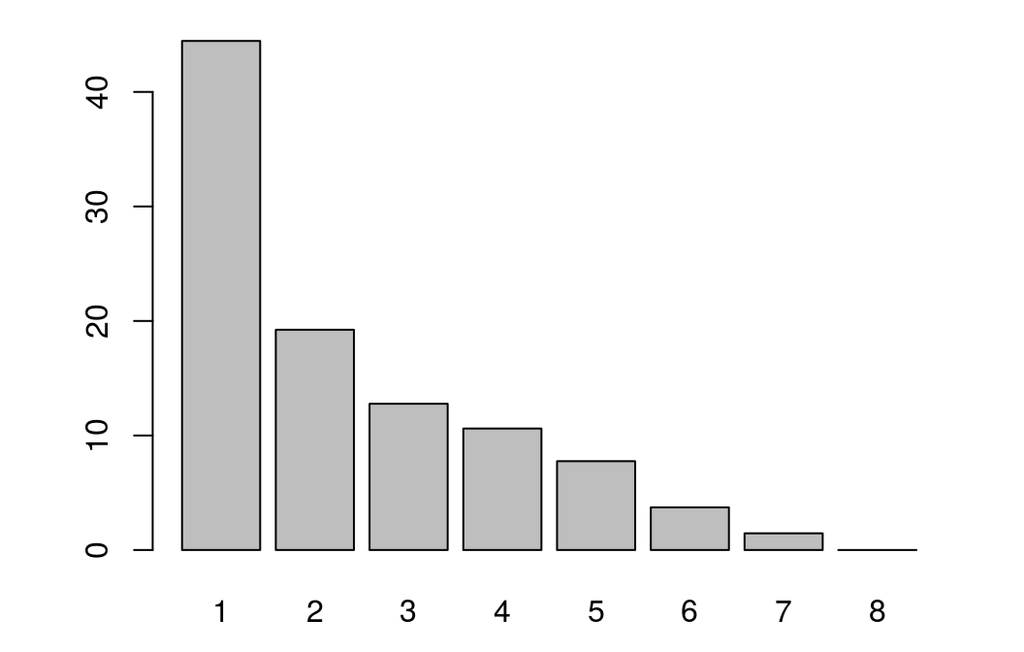

**Figure 1 - Decomposition of the total inertia on the components of the PCA**

An estimation of the right number of axis to interpret suggests to restrict the analysis to the description of the first 1 axis. These axis present an amount of inertia greater than those obtained by the 0.95-quantile of random distributions (44.45% against 29.11%). This observation suggests that only this axis is carrying a real information. As a consequence, the description will stand to these axis.

### 2. Description of the dimension 1

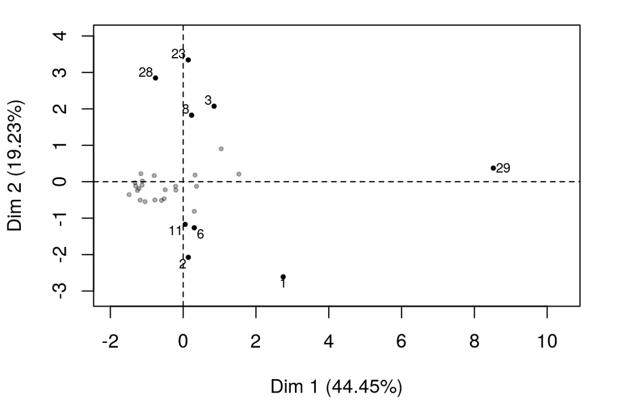

**Figure 2.1 - Individuals factor map (PCA)** *The labeled individuals are those with the higher contribution to the plane construction.*

The Wilks test p-value indicates which variable factors are the best separated on the plane (i.e. which one explain the best the distance between individuals).

```
##   station
## 0.2945784
```

There only is one possible qualitative variable to illustrate the distance between individuals : *station*.

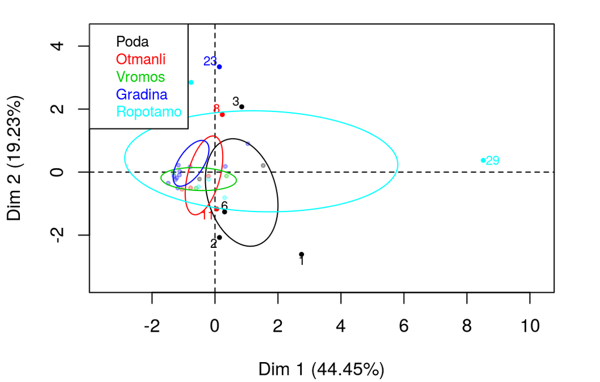

**Figure 2.2 - Individuals factor map (PCA)** *The labeled individuals are those with the higher contribution to the plane construction.* *The individuals are coloured after their category for the variable* station.

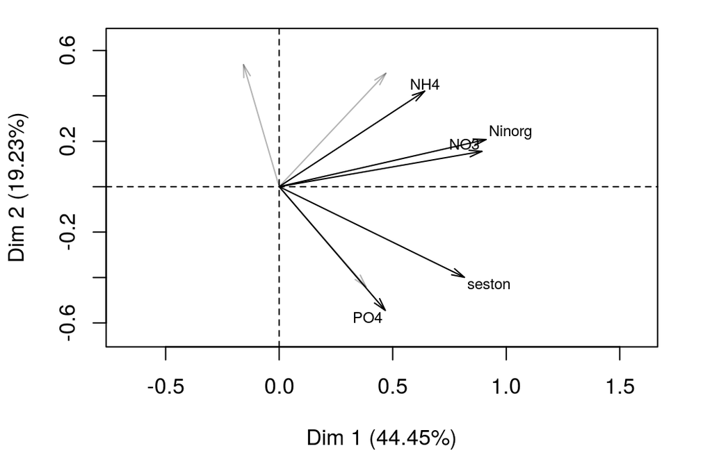

**Figure 2.3 - Variables factor map (PCA)** *The labeled variables are those the best shown on the plane.*

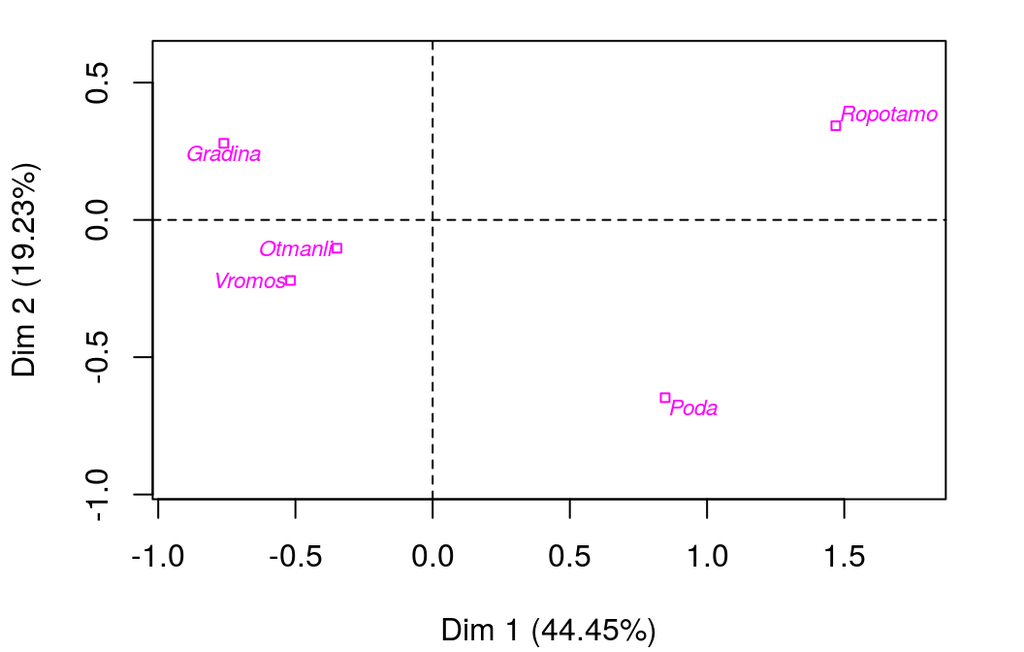

**Figure 2.4 - Qualitative factor map (PCA)** *The labeled factors are those the best shown on the plane.*

### 3. Classification

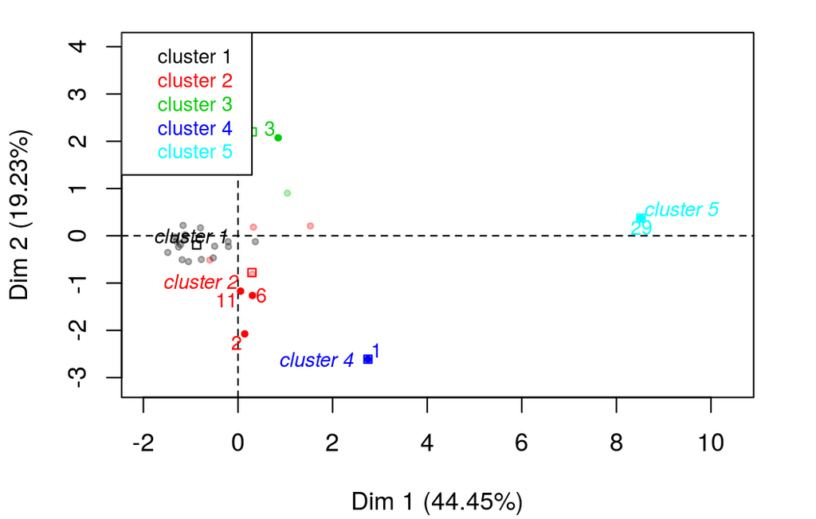

**Figure 3 - Ascending Hierarchical Classification of the individuals.** *The classification made on individuals reveals 5 clusters.*

The **cluster 1** is made of individuals sharing :

- low values for the variables *Ntotal*, *chl_a*, *NH4* and *Ninorg* (variables are sorted from the weakest).

The **cluster 2** is made of individuals such as *2*, *6* and *11*. This group is characterized by :

- high values for the variable *chl_a*.

The **cluster 3** is made of individuals such as *3*, *8*, *23* and *28*. This group is characterized by :

- high values for the variables *Ntotal* and *secchi* (variables are sorted from the strongest).

The **cluster 4** is made of individuals such as *1*. This group is characterized by :

- high values for the variables *PO4* and *seston* (variables are sorted from the strongest).

The **cluster 5** is made of individuals such as *29*. This group is characterized by :

- high values for the variables *NO3*, *Ninorg*, *seston* and *NH4* (variables are sorted from the strongest).

## Annexes

```r
dimdesc(res, axes = 1:1)
```

```
$Dim.1
$Dim.1$quanti
       correlation      p.value
Ninorg   0.9259776 8.537064e-14
NO3      0.9076408 1.874132e-12
seston   0.8290176 8.360245e-09
NH4      0.6512263 7.260409e-05
Ntotal   0.4777560 6.565483e-03
PO4      0.4748104 6.954703e-03
chl_a    0.3883944 3.083474e-02
```

**Figure 4 - List of variables characterizing the dimensions of the analysis.**

```r
res.hcpc$desc.var
```

```
Link between the cluster variable and the quantitative variables
================================================================
            Eta2      P-value
Ninorg 0.9482579 2.539311e-16
NO3    0.9443446 6.526451e-16
PO4    0.9286933 1.610919e-14
chl_a  0.8353064 7.777557e-10
seston 0.7531391 1.364379e-07
Ntotal 0.7143280 8.680347e-07
NH4    0.4736775 1.702377e-03
secchi 0.3006275 4.700343e-02

Description of each cluster by quantitative variables
=====================================================
$`1`
          v.test Mean in category  Overall mean sd in category Overall sd
Ninorg -2.160415       -0.3521242  3.539395e-17      0.1040022  0.9837388
NH4    -2.952358       -0.4812024 -3.100119e-17      0.4750915  0.9837388
chl_a  -2.992867       -0.4878049 -4.118569e-17      0.4157299  0.9837388
Ntotal -3.276296       -0.5340007 -2.735267e-16      0.5872091  0.9837388
           p.value
Ninorg 0.030740586
NH4    0.003153568
chl_a  0.002763699
Ntotal 0.001051784

$`2`
        v.test Mean in category  Overall mean sd in category Overall sd
chl_a 4.582819         1.524083 -4.118569e-17      0.5131974  0.9837388
           p.value
chl_a 4.587482e-06

$`3`
         v.test Mean in category  Overall mean sd in category Overall sd
Ntotal 4.018287        1.6457420 -2.735267e-16      0.3655284  0.9837388
secchi 2.847530        0.9757489 -8.673617e-17      1.4630926  0.8230549
            p.value
Ntotal 5.862285e-05
secchi 4.406000e-03

$`4`
         v.test Mean in category Overall mean sd in category Overall sd
PO4    5.007115         4.925693 4.957952e-17              0  0.9837388
seston 2.748017         2.703330 3.184057e-17              0  0.9837388
            p.value
PO4    5.525183e-07
seston 5.995696e-03

$`5`
         v.test Mean in category  Overall mean sd in category Overall sd
NO3    5.215643         5.130830  5.595882e-18              0  0.9837388
Ninorg 5.153889         5.070080  3.539395e-17              0  0.9837388
seston 3.615195         3.556408  3.184057e-17              0  0.9837388
NH4    2.700965         2.657044 -3.100119e-17              0  0.9837388
            p.value
NO3    1.831811e-07
Ninorg 2.551393e-07
seston 3.001212e-04
NH4    6.913854e-03
```

**Figure 5 - List of variables characterizing the clusters of the classification.**